# Oxford Township School District — NJ School Data Almanac – NJ District Profiles

NJ School Data Almanac

Oxford Township School District

WARREN COUNTY · TRADITIONAL PUBLIC DISTRICT · DFG DE · 248 STUDENTS (2026)

248

Students

50%

Gr 3-8 ELA

7.9%

Chronically absent

$19,527

Per pupil

*7 things the data says about Oxford Township School District. Every figure is computed from New Jersey Department of Education data via the njschooldata package — nothing is estimated. Comparisons use District Factor Group (DFG) peers (83 districts in DFG DE).*

No. 1 ACHIEVEMENT

## Oxford Township Girls Pass NJSLA Reading at 57.8%, Boys at 34.6% — a 23-Point Gap

On the 2024 state reading test for grades 3-8, the district’s female students outscored their male classmates by more than 23 percentage points.

When Oxford Township’s students sat for the 2024 NJSLA reading test, a striking divide emerged inside the small K-8 district: 57.8% of female students scored proficient or above, compared with just 34.6% of male students — a gap of 23.2 percentage points. The district’s overall ELA proficiency landed at 50.0%, meaning the female result pulled the average up while the male result dragged it down.

Gender gaps in reading are common nationally, but a spread this wide in a district of roughly 250 students means the pattern shows up in a handful of classrooms, not a statistical haze. The contrast also reframes the district’s headline ELA number: a 50.0% pass rate looks like a coin flip until it is split by sex, at which point girls clear it comfortably and boys fall well short.

The data also show that students who are economically disadvantaged passed ELA at 50.0%, identical to the district average and only four points behind their non-disadvantaged peers at 54.1% — a far narrower divide than the gender gap. With so few students per grade, what specifically is happening in Oxford Township’s reading instruction that boys are not getting and girls are?

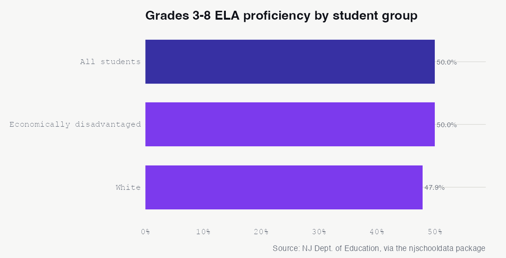

See the underlying data ›

No. 2 ACHIEVEMENT

## Oxford Township’s Reading Scores Bounced Back to 50%, but Math Never Recovered From COVID

ELA proficiency returned above its pre-pandemic level by 2024 while math proficiency, at 37.5%, still sits below where it was in 2019.

Oxford Township’s two core subjects took divergent paths out of the pandemic. On the NJSLA reading test, proficiency fell from 49.7% in 2019 to 37.4% in 2022 — a 12.3-point COVID-era drop — but then climbed back to 48.8% in 2023 and 50.0% in 2024, edging past its pre-pandemic mark. Math told a different story. Proficiency slipped from 38.9% in 2019 to 34.2% in 2022, stayed stuck at 34.2% in 2023, and recovered only to 37.5% in 2024 — still short of where it stood before schools closed.

Reading recovery suggests the district can move the needle when it focuses. Why has math proficiency proven so much stickier, and what would it take to close the 12.5-point gap with reading?

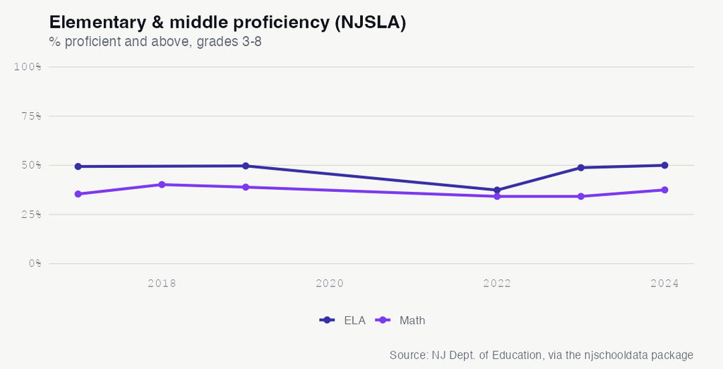

See the underlying data ›

No. 3 EQUITY

Economic need surged from 34 students in 2023 to 76 in 2026, the highest share on record for the district.

The 2026 share is the highest in the district’s recorded data and represents more than a doubling from the 2022 low. Because lunch eligibility is one of the few consistent local measures of family economic hardship, the jump signals a meaningful change in the financial circumstances of Oxford Township families over a short window.

Notably, the district reports zero students classified as English learners across every year on record, so this rising need is not tied to newly arrived immigrant families learning English. Encouragingly, the 2024 NJSLA results show students who are economically disadvantaged passing ELA at the same 50.0% rate as the district overall. What is driving so many more Oxford Township families to qualify for meal assistance, and can the district hold that parity as economic need climbs?

See the underlying data ›

No. 4 DEMOGRAPHICS

## Once 94% White, Oxford Township’s Student Body Is Now 78% White

The share of students who are white fell 15.6 percentage points since 2015 as Hispanic and Black enrollment grew.

A decade ago, Oxford Township was among New Jersey’s most racially homogeneous districts: in 2015, 93.8% of its students were white, with Hispanic students making up just 4.6% and Black students 0.7%. By 2026, the white share had fallen to 78.2%, a drop of 15.6 percentage points and the single largest demographic change in the district over that span.

The gains came across multiple groups. The Hispanic share rose 9.1 points to 13.7%, and the Black share climbed 4.2 points to 4.8%. The shift accelerated noticeably after 2020, when the white share stood at 90.3% — within four years it had fallen below 75% before settling back to 78.2%.

Demographic change of this scale in a district of roughly 250 students reflects who is moving into and out of a small rural community. As Oxford Township’s classrooms grow more diverse, how will the district adapt its programming and family outreach to serve students whose backgrounds increasingly differ from the community it served a decade ago?

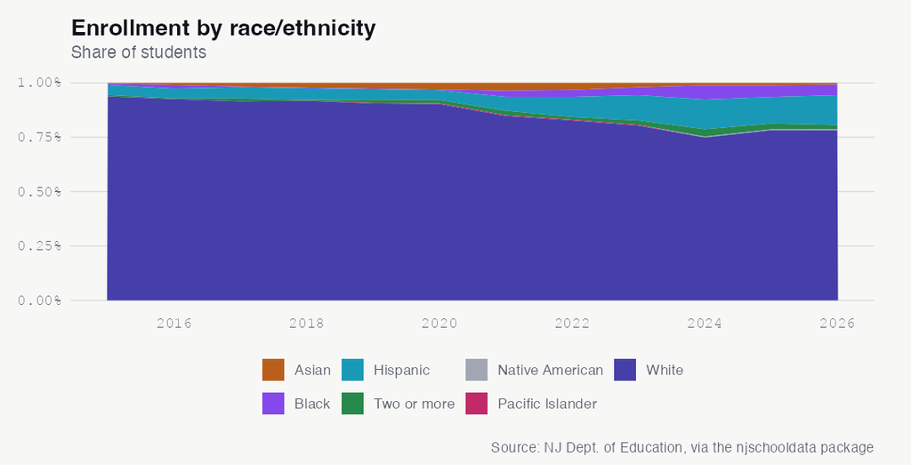

See the underlying data ›

No. 5 ATTENDANCE

## Oxford Township’s Chronic Absenteeism, 7.9%, Runs Far Below the 13.6% Peer Median

After a pandemic spike to 25.9%, the district’s chronic absenteeism rate recovered to nearly its pre-COVID level.

Oxford Township kept just 7.9% of its students chronically absent in 2024, well under the 13.6% median for its District Factor Group peers. Being chronically absent means missing at least 10% of school days, and on this measure the small rural district outperforms most districts that serve similar communities.

The recovery is notable given how sharply attendance unraveled during the pandemic. The chronic absenteeism rate spiked to 25.9% in 2022 from 10.4% the prior year, before falling to 12.8% in 2023 and then to 7.9% in 2024 — within striking distance of the 6.6% rate the district posted in 2019, before COVID disruptions.

For families weighing where to enroll, consistent attendance is one of the clearest signals that students are showing up and engaged. Can Oxford Township hold its attendance edge over peers as its enrollment shifts and economic need rises?

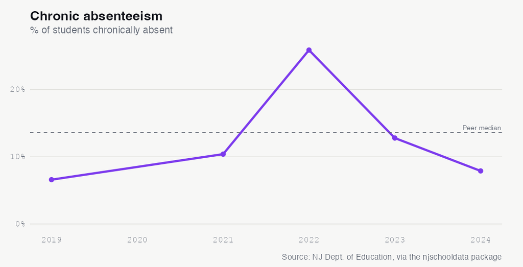

See the underlying data ›

No. 6 ENROLLMENT

## Oxford Township Schools Hit Their Lowest Enrollment on Record at 248 Students

The K-8 Warren County district has shed nearly one in five students since 2015, with this year marking a new low.

Oxford Township enrolled 248 students in 2026, the smallest count in the district’s recorded history and a drop of 58 students, or 19.0%, from the 306 it served in 2015. The district peaked at 308 students in 2016 and has trended downward almost every year since, sliding to 274 by 2019 and then to 249 by 2022.

Much of the steepest loss clustered around the pandemic: between 2019 and 2022 the district lost 25 students, a 9.1% decline. A brief rebound interrupted the slide in 2024, when enrollment rose by 14 students to 263 — the only meaningful gain in the past decade — but the recovery proved short-lived, with counts falling to 262 in 2025 and 248 in 2026.

For a rural district this small, every departing cohort reshapes class sizes, staffing math, and per-pupil costs. Will the 2024 uptick prove to be a one-year anomaly, or can Oxford Township stabilize a decade-long decline before the next budget cycle?

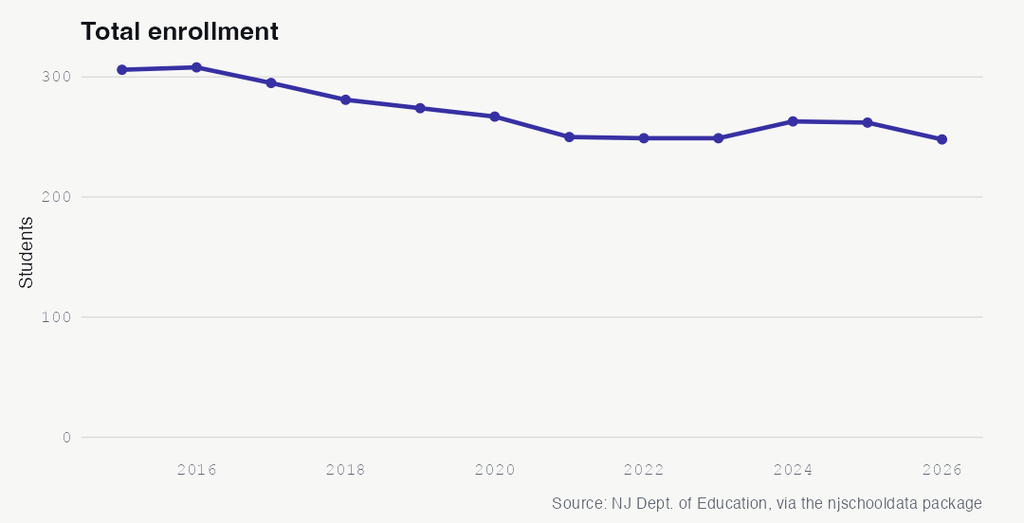

See the underlying data ›

No. 7 FINANCE

## Oxford Township Now Spends $19,527 per Student, Up 48.7% as Enrollment Shrank

Per-pupil spending climbed nearly half over a decade even as the district’s average daily enrollment fell from 313 to 262.

Oxford Township spent $19,527 per pupil in 2024, up 48.7% from $13,129 in 2014. That places the district at the 60th percentile among its District Factor Group peers, modestly above the peer median of $18,964 — a typical position for a very small district, where fixed costs spread across few students.

The rising per-pupil figure tracks closely with falling enrollment. The district’s average daily enrollment slid from 313 students in 2014 to a low of 249 in 2023 before recovering to 262 in 2024. With fewer students to absorb the cost of running a school, the price tag per child climbs even when total spending holds steady. Of every dollar spent in 2025, 59.5% went to the classroom, 20.4% to support services, 9.2% to plant operations, and 8.9% to administration.

The arithmetic of small-district budgeting is unforgiving: as enrollment falls, per-pupil costs tend to rise regardless of how efficiently a district operates. How long can Oxford Township sustain near-$20,000-per-student spending if its enrollment decline resumes?

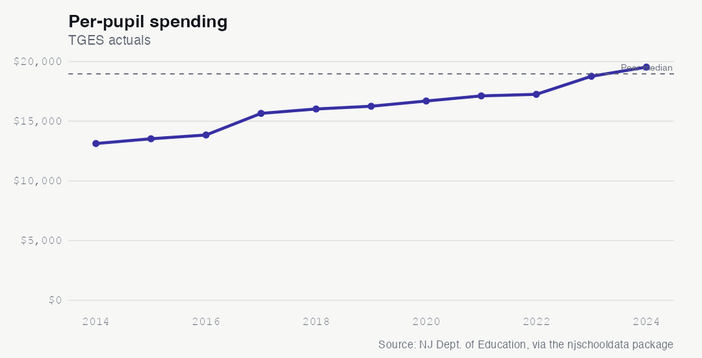

See the underlying data ›

## The Almanac

The full longitudinal record behind the stories above. Every number a reader can check.

### Enrollment (total)

| year | students | yoy | yoy_pct |
| --- | --- | --- | --- |
| 2015 | 306 | NA | NA |
| 2016 | 308 | 2 | 0.7 |
| 2017 | 295 | -13 | -4.2 |
| 2018 | 281 | -14 | -4.7 |
| 2019 | 274 | -7 | -2.5 |
| 2020 | 267 | -7 | -2.6 |
| 2021 | 250 | -17 | -6.4 |
| 2022 | 249 | -1 | -0.4 |
| 2023 | 249 | 0 | 0 |
| 2024 | 263 | 14 | 5.6 |
| 2025 | 262 | -1 | -0.4 |
| 2026 | 248 | -14 | -5.3 |

### Demographic share (%) by year

| end_year | white | black | hispanic | asian | native_american | pacific_islander | multiracial |
| --- | --- | --- | --- | --- | --- | --- | --- |
| 2015 | 93.8 | 0.7 | 4.6 | 0.3 | 0 | 0 | 0.7 |
| 2016 | 92.5 | 1.6 | 4.5 | 1 | 0 | 0 | 0.3 |
| 2017 | 91.5 | 0.3 | 5.1 | 1.7 | 0 | 0 | 1.4 |
| 2018 | 91.8 | 0.4 | 5.3 | 2.1 | 0 | 0 | 0.4 |
| 2019 | 90.5 | 0.4 | 4.7 | 2.6 | 0 | 0.4 | 1.5 |
| 2020 | 90.3 | 0.4 | 4.5 | 3 | 0 | 0.4 | 1.5 |
| 2021 | 84.8 | 2.8 | 6.4 | 3.6 | 0 | 0.4 | 2 |
| 2022 | 82.7 | 3.2 | 9.2 | 3.2 | 0 | 0.4 | 1.2 |
| 2023 | 80.3 | 3.6 | 11.6 | 2 | 0 | 0.4 | 2 |
| 2024 | 74.9 | 6.5 | 13.7 | 1.1 | 0.4 | 0 | 3.4 |
| 2025 | 78.2 | 5.3 | 12.2 | 1.1 | 0.4 | 0 | 2.7 |
| 2026 | 78.2 | 4.8 | 13.7 | 0.8 | 0.4 | 0 | 2 |

### Special populations (LEP, FRL)

| end_year | subgroup | students | pct |
| --- | --- | --- | --- |
| 2015 | lep | 0 | 0.0 |
| 2015 | free_reduced_lunch | 47 | 15.4 |
| 2016 | lep | 0 | 0.0 |
| 2016 | free_reduced_lunch | 61 | 19.8 |
| 2017 | lep | 0 | 0.0 |
| 2017 | free_reduced_lunch | 49 | 16.6 |
| 2018 | lep | 0 | 0.0 |
| 2018 | free_reduced_lunch | 38 | 13.5 |
| 2019 | lep | 0 | 0.0 |
| 2019 | free_reduced_lunch | 38 | 13.9 |
| 2020 | lep | 0 | 0.0 |
| 2020 | free_reduced_lunch | 45 | 16.8 |
| 2021 | lep | 0 | 0.0 |
| 2021 | free_reduced_lunch | 42 | 16.8 |
| 2022 | lep | 0 | 0.0 |
| 2022 | free_reduced_lunch | 30 | 12.0 |
| 2023 | lep | 0 | 0.0 |
| 2023 | free_reduced_lunch | 34 | 13.6 |
| 2024 | lep | 0 | 0.0 |
| 2024 | free_reduced_lunch | 47 | 17.8 |
| 2025 | lep | 0 | 0.0 |
| 2025 | free_reduced_lunch | 78 | 29.8 |
| 2026 | lep | 0 | 0.0 |
| 2026 | free_reduced_lunch | 76 | 30.6 |

### NJSLA grades 3-8 proficiency (% proficient+, enrollment-weighted across grades)

| testing_year | test_name | prof |
| --- | --- | --- |
| 2017 | ela | 49.4 |
| 2017 | math | 35.4 |
| 2018 | math | 40.2 |
| 2019 | ela | 49.7 |
| 2019 | math | 38.9 |
| 2022 | ela | 37.4 |
| 2022 | math | 34.2 |
| 2023 | ela | 48.8 |
| 2023 | math | 34.2 |
| 2024 | ela | 50.0 |
| 2024 | math | 37.5 |

### NJSLA ELA proficiency by subgroup (2024, grades 3-8)

| subgroup | prof |
| --- | --- |
| female | 57.8 |
| non_ed | 54.1 |
| ed | 50.0 |
| total_population | 50.0 |
| white | 47.9 |
| male | 34.6 |

### Chronic absenteeism (% chronically absent)

| year | chronic_pct |
| --- | --- |
| 2019 | 6.6 |
| 2021 | 10.4 |
| 2022 | 25.9 |
| 2023 | 12.8 |
| 2024 | 7.9 |

### Disciplinary removals

[output not shown]

### Police notifications (incident counts)

| year | violence | weapons | vandalism | substances | hib | other |
| --- | --- | --- | --- | --- | --- | --- |
| 2019 | 2 | 0 | 0 | 0 | 1 | 0 |
| 2020 | 0 | 0 | 0 | 0 | 0 | 1 |
| 2021 | 1 | 0 | 0 | 0 | 0 | 0 |
| 2022 | 1 | 1 | 0 | 0 | 2 | 0 |
| 2023 | 0 | 0 | 0 | 0 | 2 | 0 |
| 2024 | 0 | 0 | 0 | 0 | 0 | 0 |

### HIB (harassment/intimidation/bullying) investigations

| end_year | alleged | confirmed |
| --- | --- | --- |
| 2019 | 3 | 4 |
| 2020 | 0 | 4 |
| 2021 | 0 | 0 |
| 2022 | 0 | 8 |
| 2023 | 0 | 12 |
| 2024 | 0 | 2 |

### Special education (raw rows; inspect for classification rate)

| end_year | district_id |
| --- | --- |
| 2024 | 3890 |

### Per-pupil spending (TGES actuals)

| year | per_pupil | rank | ade |
| --- | --- | --- | --- |
| 2014 | 13129 | 16 | 313 |
| 2015 | 13528 | 17 | 308 |
| 2016 | 13844 | 17 | 309 |
| 2017 | 15654 | 23 | 292 |
| 2018 | 16022 | 21 | 276 |
| 2019 | 16251 | 20 | 280 |
| 2020 | 16690 | 27 | 265 |
| 2021 | 17118 | 29 | 259 |
| 2022 | 17248 | 21 | 254 |
| 2023 | 18761 | 32 | 249 |
| 2024 | 19527 | 25 | 262 |

### Spending composition shares (2025)

| classroom_share | support_services_share | administration_share | plant_ops_share | food_service_share | extracurricular_share | equipment_share |
| --- | --- | --- | --- | --- | --- | --- |
| 59.5 | 20.4 | 8.9 | 9.2 | NA | 0.5 | 0.9 |

### Staffing ratios

| end_year | student_teacher_district | student_admin_district | student_counselor_district | student_nurse_district |
| --- | --- | --- | --- | --- |
| 2024 | 8:1 | 136:1 | 271:1 | 271:1 |

Back to top